# Students' Examination Performance Data - Communicate Findings

## by Dorothy Kambua Thomas

## Investigation Overview

> I aimed to analyze the students' overall score and the factors that affect a student's overall score in examination. I focused on various attributes present in the student examination performance data - gender, lunch details, completion of test preparation course, parental education, and test scores including math, reading, writing, and total scores.

## Dataset Overview

> The Student Examination Performance dataset consist of data about the performance of various students in school. The data includes various information about each student: Gender Race/ethnicity, Parental level of education, Lunch details eg, standard, free, or reduced, Completion of test preparation course, Test scores, i.e., reading, writing, math, and total score.

## Distribution of the Overall (Total) Score

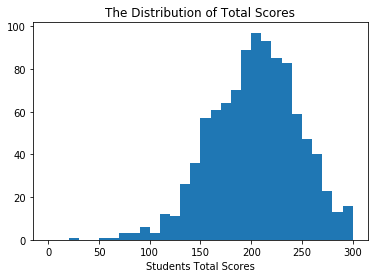

## Math Score Distribution

> Math score distribution is close to normal. Many students had a math score of between 60 and 80.

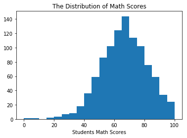

## The bilateral relationship between parental education and test preparation course completion

The students whose parents have an associate degree are the ones who mostly completed the preparation test. The students whose parents attended some college are the ones who mostly failed to complete the preparation test.

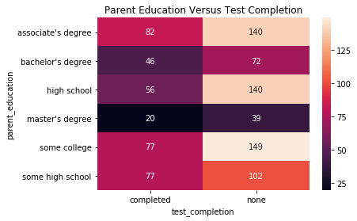

## Multilateral effect of categorical features against the bilateral relationship of total score and other scores.

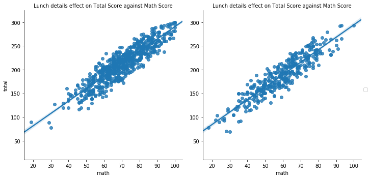

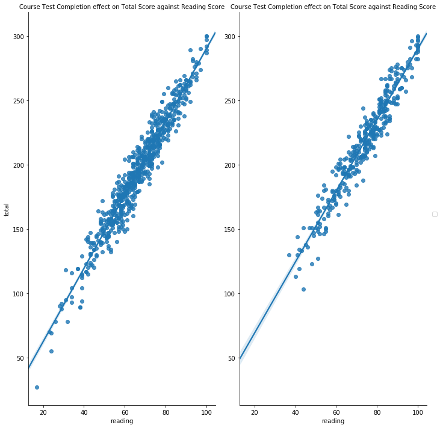

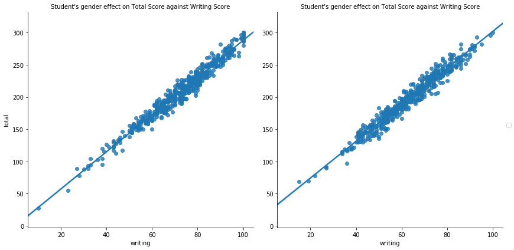